# Starbucks Capstone Challenge

### Introduction

This data set contains simulated data that mimics customer behavior on the Starbucks rewards mobile app. Once every few days, Starbucks sends out an offer to users of the mobile app. An offer can be merely an advertisement for a drink or an actual offer such as a discount or BOGO (buy one get one free). Some users might not receive any offer during certain weeks.

Not all users receive the same offer, and that is the challenge to solve with this data set.

Your task is to combine transaction, demographic and offer data to determine which demographic groups respond best to which offer type. This data set is a simplified version of the real Starbucks app because the underlying simulator only has one product whereas Starbucks actually sells dozens of products.

Every offer has a validity period before the offer expires. As an example, a BOGO offer might be valid for only 5 days. You'll see in the data set that informational offers have a validity period even though these ads are merely providing information about a product; for example, if an informational offer has 7 days of validity, you can assume the customer is feeling the influence of the offer for 7 days after receiving the advertisement.

You'll be given transactional data showing user purchases made on the app including the timestamp of purchase and the amount of money spent on a purchase. This transactional data also has a record for each offer that a user receives as well as a record for when a user actually views the offer. There are also records for when a user completes an offer.

Keep in mind as well that someone using the app might make a purchase through the app without having received an offer or seen an offer.

### Example

To give an example, a user could receive a discount offer buy 10 dollars get 2 off on Monday. The offer is valid for 10 days from receipt. If the customer accumulates at least 10 dollars in purchases during the validity period, the customer completes the offer.

However, there are a few things to watch out for in this data set. Customers do not opt into the offers that they receive; in other words, a user can receive an offer, never actually view the offer, and still complete the offer. For example, a user might receive the "buy 10 dollars get 2 dollars off offer", but the user never opens the offer during the 10 day validity period. The customer spends 15 dollars during those ten days. There will be an offer completion record in the data set; however, the customer was not influenced by the offer because the customer never viewed the offer.

### Cleaning

This makes data cleaning especially important and tricky.

You'll also want to take into account that some demographic groups will make purchases even if they don't receive an offer. From a business perspective, if a customer is going to make a 10 dollar purchase without an offer anyway, you wouldn't want to send a buy 10 dollars get 2 dollars off offer. You'll want to try to assess what a certain demographic group will buy when not receiving any offers.

### Final Advice

Because this is a capstone project, you are free to analyze the data any way you see fit. For example, you could build a machine learning model that predicts how much someone will spend based on demographics and offer type. Or you could build a model that predicts whether or not someone will respond to an offer. Or, you don't need to build a machine learning model at all. You could develop a set of heuristics that determine what offer you should send to each customer (i.e., 75 percent of women customers who were 35 years old responded to offer A vs 40 percent from the same demographic to offer B, so send offer A).

# Data Sets

The data is contained in three files:

- portfolio.json - containing offer ids and meta data about each offer (duration, type, etc.)
- profile.json - demographic data for each customer
- transcript.json - records for transactions, offers received, offers viewed, and offers completed

Here is the schema and explanation of each variable in the files:

**portfolio.json**

- id (string) - offer id
- offer_type (string) - type of offer ie BOGO, discount, informational
- difficulty (int) - minimum required spend to complete an offer
- reward (int) - reward given for completing an offer
- duration (int) - time for offer to be open, in days
- channels (list of strings)

**profile.json**

- age (int) - age of the customer
- became_member_on (int) - date when customer created an app account
- gender (str) - gender of the customer (note some entries contain 'O' for other rather than M or F)
- id (str) - customer id
- income (float) - customer's income

**transcript.json**

- event (str) - record description (ie transaction, offer received, offer viewed, etc.)
- person (str) - customer id
- time (int) - time in hours since start of test. The data begins at time t=0
- value - (dict of strings) - either an offer id or transaction amount depending on the record

**Note:** If you are using the workspace, you will need to go to the terminal and run the command `conda update pandas` before reading in the files. This is because the version of pandas in the workspace cannot read in the transcript.json file correctly, but the newest version of pandas can. You can access the termnal from the orange icon in the top left of this notebook.

You can see how to access the terminal and how the install works using the two images below. First you need to access the terminal:

[figure not shown]

Then you will want to run the above command:

[figure not shown]

Finally, when you enter back into the notebook (use the jupyter icon again), you should be able to run the below cell without any errors.

## Data Sets

The data is contained in three files:

- portfolio.json - containing offer ids and meta data about each offer (duration, type, etc.)
- profile.json - demographic data for each customer
- transcript.json - records for transactions, offers received, offers viewed, and offers completed
- Here is the schema and explanation of each variable in the files:

#### portfolio.json

- id (string) - offer id
- offer_type (string) - type of offer ie BOGO, discount, informational
- difficulty (int) - minimum required spend to complete an offer
- reward (int) - reward given for completing an offer
- duration (int) - time for offer to be open, in days
- channels (list of strings)

#### profile.json

- age (int) - age of the customer
- became_member_on (int) - date when customer created an app account
- gender (str) - gender of the customer (note some entries contain 'O' for other rather than M or F)
- id (str) - customer id
- income (float) - customer's income

#### transcript.json

- event (str) - record description (ie transaction, offer received, offer viewed, etc.)
- person (str) - customer id
- time (int) - time in hours since start of test. The data begins at time t=0
- value - (dict of strings) - either an offer id or transaction amount depending on the record

```python
## IMPORTING LIBRARIES
import pandas as pd
import numpy as np
import math
import json
from tqdm import tqdm
from warnings import filterwarnings

from sklearn.model_selection import train_test_split
from sklearn.preprocessing import StandardScaler
from sklearn.tree import DecisionTreeClassifier
from sklearn.ensemble import RandomForestClassifier
from sklearn.preprocessing import PolynomialFeatures
from sklearn.metrics import mean_squared_error
from sklearn.metrics import classification_report
from sklearn.metrics import accuracy_score, f1_score, precision_score, recall_score, confusion_matrix
from time import time
from sklearn.model_selection import GridSearchCV
import matplotlib.pyplot as plt
from sklearn.linear_model import Ridge
from sklearn.tree import DecisionTreeRegressor
import matplotlib.pyplot as plt
import statistics
from scipy.stats import norm
from sklearn.linear_model import LinearRegression
from sklearn.model_selection import train_test_split
from sklearn.metrics import r2_score, mean_squared_error
from collections import defaultdict
from sklearn.feature_selection import SelectKBest
from sklearn.feature_selection import f_regression
%matplotlib inline

import seaborn as sns
import matplotlib.pyplot as plt

from sklearn.preprocessing import StandardScaler
import tensorflow as tf
import keras

# read in the json files
portfolio = pd.read_json('data/portfolio.json', orient='records', lines=True)
profile = pd.read_json('data/profile.json', orient='records', lines=True)
transcript = pd.read_json('data/transcript.json', orient='records', lines=True)
```

# Data Exploration

## 1. Portfolio Data

```python
portfolio.shape
```

```
(10, 6)
```

```python
portfolio.head()
```

|  | channels | difficulty | duration | id | offer_type | reward |
| --- | --- | --- | --- | --- | --- | --- |
| 0 | [email, mobile, social] | 10 | 7 | ae264e3637204a6fb9bb56bc8210ddfd | bogo | 10 |
| 1 | [web, email, mobile, social] | 10 | 5 | 4d5c57ea9a6940dd891ad53e9dbe8da0 | bogo | 10 |
| 2 | [web, email, mobile] | 0 | 4 | 3f207df678b143eea3cee63160fa8bed | informational | 0 |
| 3 | [web, email, mobile] | 5 | 7 | 9b98b8c7a33c4b65b9aebfe6a799e6d9 | bogo | 5 |
| 4 | [web, email] | 20 | 10 | 0b1e1539f2cc45b7b9fa7c272da2e1d7 | discount | 5 |

```python
portfolio.describe()
```

|  | difficulty | duration | reward |
| --- | --- | --- | --- |
| count | 10.000000 | 10.000000 | 10.000000 |
| mean | 7.700000 | 6.500000 | 4.200000 |
| std | 5.831905 | 2.321398 | 3.583915 |
| min | 0.000000 | 3.000000 | 0.000000 |
| 25% | 5.000000 | 5.000000 | 2.000000 |
| 50% | 8.500000 | 7.000000 | 4.000000 |
| 75% | 10.000000 | 7.000000 | 5.000000 |
| max | 20.000000 | 10.000000 | 10.000000 |

```python
portfolio.info()
```

```
<class 'pandas.core.frame.DataFrame'>
RangeIndex: 10 entries, 0 to 9
Data columns (total 6 columns):
channels      10 non-null object
difficulty    10 non-null int64
duration      10 non-null int64
id            10 non-null object
offer_type    10 non-null object
reward        10 non-null int64
dtypes: int64(3), object(3)
memory usage: 560.0+ bytes
```

```python
portfolio['channels']
```

```
0         [email, mobile, social]
1    [web, email, mobile, social]
2            [web, email, mobile]
3            [web, email, mobile]
4                    [web, email]
5    [web, email, mobile, social]
6    [web, email, mobile, social]
7         [email, mobile, social]
8    [web, email, mobile, social]
9            [web, email, mobile]
Name: channels, dtype: object
```

#### There are four different types of the channels:

```
- web
- email
- mobile
- social
```

```python
portfolio['offer_type'].value_counts()
```

```
bogo             4
discount         4
informational    2
Name: offer_type, dtype: int64
```

#### There are three different types of the offer types:

```
- bogo
- discount
- informational
```

- In a BOGO offer, a user needs to spend a certain amount to get a reward equal to that threshold amount.
- In a discount, a user gains a reward equal to a fraction of the amount spent.
- In an informational offer, there is no reward, but neither is there a requisite amount that the user is expected to spend.

## 2. Profile Data

```python
profile.shape
```

```
(17000, 5)
```

```python
profile.head()
```

|  | age | became_member_on | gender | id | income |
| --- | --- | --- | --- | --- | --- |
| 0 | 118 | 20170212 | None | 68be06ca386d4c31939f3a4f0e3dd783 | NaN |
| 1 | 55 | 20170715 | F | 0610b486422d4921ae7d2bf64640c50b | 112000.0 |
| 2 | 118 | 20180712 | None | 38fe809add3b4fcf9315a9694bb96ff5 | NaN |
| 3 | 75 | 20170509 | F | 78afa995795e4d85b5d9ceeca43f5fef | 100000.0 |
| 4 | 118 | 20170804 | None | a03223e636434f42ac4c3df47e8bac43 | NaN |

```python
profile.describe()
```

|  | age | became_member_on | income |
| --- | --- | --- | --- |
| count | 17000.000000 | 1.700000e+04 | 14825.000000 |
| mean | 62.531412 | 2.016703e+07 | 65404.991568 |
| std | 26.738580 | 1.167750e+04 | 21598.299410 |
| min | 18.000000 | 2.013073e+07 | 30000.000000 |
| 25% | 45.000000 | 2.016053e+07 | 49000.000000 |
| 50% | 58.000000 | 2.017080e+07 | 64000.000000 |
| 75% | 73.000000 | 2.017123e+07 | 80000.000000 |
| max | 118.000000 | 2.018073e+07 | 120000.000000 |

```python
profile.info()
```

```
<class 'pandas.core.frame.DataFrame'>
RangeIndex: 17000 entries, 0 to 16999
Data columns (total 5 columns):
age                 17000 non-null int64
became_member_on    17000 non-null int64
gender              14825 non-null object
id                  17000 non-null object
income              14825 non-null float64
dtypes: float64(1), int64(2), object(2)
memory usage: 664.1+ KB
```

```python
profile['gender'].value_counts()
```

```
M    8484
F    6129
O     212
Name: gender, dtype: int64
```

#### There are three different types of the user gender:

[output not shown]

```python
profile.isnull().sum()
```

```
age                    0
became_member_on       0
gender              2175
id                     0
income              2175
dtype: int64
```

```python
#Age Column
profile[profile.age == 118][['gender','age','income']].head()
```

|  | gender | age | income |
| --- | --- | --- | --- |
| 0 | None | 118 | NaN |
| 2 | None | 118 | NaN |
| 4 | None | 118 | NaN |
| 6 | None | 118 | NaN |
| 7 | None | 118 | NaN |

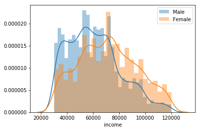

```python
## Gender-wise Income Distribution
sns.distplot(profile[profile.gender=='M'].income,label='Male')
sns.distplot(profile[profile.gender=='F'].income,label='Female')
plt.legend()
plt.show()
```

## 3. Transcript Data

```python
transcript.shape
```

```
(306534, 4)
```

```python
transcript.head()
```

|  | event | person | time | value |
| --- | --- | --- | --- | --- |
| 0 | offer received | 78afa995795e4d85b5d9ceeca43f5fef | 0 | {'offer id': '9b98b8c7a33c4b65b9aebfe6a799e6d9'} |
| 1 | offer received | a03223e636434f42ac4c3df47e8bac43 | 0 | {'offer id': '0b1e1539f2cc45b7b9fa7c272da2e1d7'} |
| 2 | offer received | e2127556f4f64592b11af22de27a7932 | 0 | {'offer id': '2906b810c7d4411798c6938adc9daaa5'} |
| 3 | offer received | 8ec6ce2a7e7949b1bf142def7d0e0586 | 0 | {'offer id': 'fafdcd668e3743c1bb461111dcafc2a4'} |
| 4 | offer received | 68617ca6246f4fbc85e91a2a49552598 | 0 | {'offer id': '4d5c57ea9a6940dd891ad53e9dbe8da0'} |

```python
transcript.info()
```

```
<class 'pandas.core.frame.DataFrame'>
RangeIndex: 306534 entries, 0 to 306533
Data columns (total 4 columns):
event     306534 non-null object
person    306534 non-null object
time      306534 non-null int64
value     306534 non-null object
dtypes: int64(1), object(3)
memory usage: 9.4+ MB
```

```python
transcript.describe()
```

|  | time |
| --- | --- |
| count | 306534.000000 |
| mean | 366.382940 |
| std | 200.326314 |
| min | 0.000000 |
| 25% | 186.000000 |
| 50% | 408.000000 |
| 75% | 528.000000 |
| max | 714.000000 |

```python
transcript['event'].value_counts()
```

```
transaction        138953
offer received      76277
offer viewed        57725
offer completed     33579
Name: event, dtype: int64
```

#### There are four different stages of the transcript events:

```
- transaction
- offer received
- offer viewed
- offer completed
```

# Data Cleaning and Wrangling

## 1. Portfolio Data Preprocessing

```python
df_portfolio = portfolio.copy()

dummy = pd.get_dummies(df_portfolio.channels.apply(pd.Series).stack()).sum(level=0)
df_portfolio = pd.concat([df_portfolio, dummy], axis=1)
df_portfolio = df_portfolio.drop(columns='channels')

df_portfolio = df_portfolio.rename(columns={'id':'offer_id'})
```

```python
df_portfolio
```

|  | difficulty | duration | offer_id | offer_type | reward | email | mobile | social | web |
| --- | --- | --- | --- | --- | --- | --- | --- | --- | --- |
| 0 | 10 | 7 | ae264e3637204a6fb9bb56bc8210ddfd | bogo | 10 | 1 | 1 | 1 | 0 |
| 1 | 10 | 5 | 4d5c57ea9a6940dd891ad53e9dbe8da0 | bogo | 10 | 1 | 1 | 1 | 1 |
| 2 | 0 | 4 | 3f207df678b143eea3cee63160fa8bed | informational | 0 | 1 | 1 | 0 | 1 |
| 3 | 5 | 7 | 9b98b8c7a33c4b65b9aebfe6a799e6d9 | bogo | 5 | 1 | 1 | 0 | 1 |
| 4 | 20 | 10 | 0b1e1539f2cc45b7b9fa7c272da2e1d7 | discount | 5 | 1 | 0 | 0 | 1 |
| 5 | 7 | 7 | 2298d6c36e964ae4a3e7e9706d1fb8c2 | discount | 3 | 1 | 1 | 1 | 1 |
| 6 | 10 | 10 | fafdcd668e3743c1bb461111dcafc2a4 | discount | 2 | 1 | 1 | 1 | 1 |
| 7 | 0 | 3 | 5a8bc65990b245e5a138643cd4eb9837 | informational | 0 | 1 | 1 | 1 | 0 |
| 8 | 5 | 5 | f19421c1d4aa40978ebb69ca19b0e20d | bogo | 5 | 1 | 1 | 1 | 1 |
| 9 | 10 | 7 | 2906b810c7d4411798c6938adc9daaa5 | discount | 2 | 1 | 1 | 0 | 1 |

## 2. Profile Data Preporcessing

```python
df_profile = profile.copy()

# Convert the became_member_on into datetime type
df_profile['became_member_on'] = pd.to_datetime(df_profile['became_member_on'], format='%Y%m%d')

#Rename the id column to customer_id
df_profile = df_profile.rename(columns={'id':'customer_id'})

df_profile.head(10)
```

|  | age | became_member_on | gender | customer_id | income |
| --- | --- | --- | --- | --- | --- |
| 0 | 118 | 2017-02-12 | None | 68be06ca386d4c31939f3a4f0e3dd783 | NaN |
| 1 | 55 | 2017-07-15 | F | 0610b486422d4921ae7d2bf64640c50b | 112000.0 |
| 2 | 118 | 2018-07-12 | None | 38fe809add3b4fcf9315a9694bb96ff5 | NaN |
| 3 | 75 | 2017-05-09 | F | 78afa995795e4d85b5d9ceeca43f5fef | 100000.0 |
| 4 | 118 | 2017-08-04 | None | a03223e636434f42ac4c3df47e8bac43 | NaN |
| 5 | 68 | 2018-04-26 | M | e2127556f4f64592b11af22de27a7932 | 70000.0 |
| 6 | 118 | 2017-09-25 | None | 8ec6ce2a7e7949b1bf142def7d0e0586 | NaN |
| 7 | 118 | 2017-10-02 | None | 68617ca6246f4fbc85e91a2a49552598 | NaN |
| 8 | 65 | 2018-02-09 | M | 389bc3fa690240e798340f5a15918d5c | 53000.0 |
| 9 | 118 | 2016-11-22 | None | 8974fc5686fe429db53ddde067b88302 | NaN |

```python
## Fill the value based on the condition

# Fill the null values in age column with the mean
df_profile['age'].fillna(df_profile['age'].mean(), inplace=True)
df_profile.loc[df_profile['age'] > 100, 'age'] = df_profile['age'].median()

# Fill the null values in gender column with the mode
df_profile['gender'].fillna(method ='ffill', inplace=True)

# Fill the null values in income column with the median
df_profile['income'].fillna(df_profile['income'].mean(), inplace=True)


# Round down the age column
#df_profile['age'] = df_profile['age'].astype(int)
```

```python
df_profile.isna().sum()
```

```
age                 0
became_member_on    0
gender              1
customer_id         0
income              0
dtype: int64
```

```python
df_profile.describe()
```

|  | age | income |
| --- | --- | --- |
| count | 17000.000000 | 17000.000000 |
| mean | 54.842294 | 65404.991568 |
| std | 16.259018 | 20169.288288 |
| min | 18.000000 | 30000.000000 |
| 25% | 45.000000 | 51000.000000 |
| 50% | 58.000000 | 65404.991568 |
| 75% | 65.000000 | 76000.000000 |
| max | 100.000000 | 120000.000000 |

```python
df_profile['gender'].value_counts()
```

```
M    9718
F    7046
O     235
Name: gender, dtype: int64
```

## 3. Transcript Data Preprocessing

```python
df_transcript = transcript.copy()

df_transcript = df_transcript.rename(columns={'person':'customer_id'})

df_transcript['event'] = df_transcript['event'].str.replace(' ', '-')

df_transcript['event'].value_counts()

dummy = pd.get_dummies(df_transcript['event'])
df_transcript = pd.concat([df_transcript, dummy], axis=1 )

df_transcript.head()
```

|  | event | customer_id | time | value | offer-completed | offer-received | offer-viewed | transaction |
| --- | --- | --- | --- | --- | --- | --- | --- | --- |
| 0 | offer-received | 78afa995795e4d85b5d9ceeca43f5fef | 0 | {'offer id': '9b98b8c7a33c4b65b9aebfe6a799e6d9'} | 0 | 1 | 0 | 0 |
| 1 | offer-received | a03223e636434f42ac4c3df47e8bac43 | 0 | {'offer id': '0b1e1539f2cc45b7b9fa7c272da2e1d7'} | 0 | 1 | 0 | 0 |
| 2 | offer-received | e2127556f4f64592b11af22de27a7932 | 0 | {'offer id': '2906b810c7d4411798c6938adc9daaa5'} | 0 | 1 | 0 | 0 |
| 3 | offer-received | 8ec6ce2a7e7949b1bf142def7d0e0586 | 0 | {'offer id': 'fafdcd668e3743c1bb461111dcafc2a4'} | 0 | 1 | 0 | 0 |
| 4 | offer-received | 68617ca6246f4fbc85e91a2a49552598 | 0 | {'offer id': '4d5c57ea9a6940dd891ad53e9dbe8da0'} | 0 | 1 | 0 | 0 |

```python
df_transcript['offer_id'] = [[*i.values()][0]if [*i.keys()][0] in ['offer id','offer_id'] else None for i in df_transcript.value]
df_transcript['amount'] = [np.round([*i.values()][0], decimals=2)if [*i.keys()][0] == 'amount' else None for i in df_transcript.value]

df_transcript = df_transcript.drop(columns='value')

df_transcript.head()
```

|  | event | customer_id | time | offer-completed | offer-received | offer-viewed | transaction | offer_id | amount |
| --- | --- | --- | --- | --- | --- | --- | --- | --- | --- |
| 0 | offer-received | 78afa995795e4d85b5d9ceeca43f5fef | 0 | 0 | 1 | 0 | 0 | 9b98b8c7a33c4b65b9aebfe6a799e6d9 | NaN |
| 1 | offer-received | a03223e636434f42ac4c3df47e8bac43 | 0 | 0 | 1 | 0 | 0 | 0b1e1539f2cc45b7b9fa7c272da2e1d7 | NaN |
| 2 | offer-received | e2127556f4f64592b11af22de27a7932 | 0 | 0 | 1 | 0 | 0 | 2906b810c7d4411798c6938adc9daaa5 | NaN |
| 3 | offer-received | 8ec6ce2a7e7949b1bf142def7d0e0586 | 0 | 0 | 1 | 0 | 0 | fafdcd668e3743c1bb461111dcafc2a4 | NaN |
| 4 | offer-received | 68617ca6246f4fbc85e91a2a49552598 | 0 | 0 | 1 | 0 | 0 | 4d5c57ea9a6940dd891ad53e9dbe8da0 | NaN |

```python
df_transcript_profile = pd.merge(df_transcript, df_profile, on='customer_id')
```

```python
df = pd.merge(df_transcript_profile, df_portfolio, on='offer_id', how='left')
```

```python
offer_id = df['offer_id'].unique()
offer_id
```

```
array(['9b98b8c7a33c4b65b9aebfe6a799e6d9', None,
       '5a8bc65990b245e5a138643cd4eb9837',
       'ae264e3637204a6fb9bb56bc8210ddfd',
       'f19421c1d4aa40978ebb69ca19b0e20d',
       '0b1e1539f2cc45b7b9fa7c272da2e1d7',
       '3f207df678b143eea3cee63160fa8bed',
       '2906b810c7d4411798c6938adc9daaa5',
       'fafdcd668e3743c1bb461111dcafc2a4',
       '4d5c57ea9a6940dd891ad53e9dbe8da0',
       '2298d6c36e964ae4a3e7e9706d1fb8c2'], dtype=object)
```

```python
offer_dict = pd.Series(offer_id ).to_dict()
offer_dict
```

```
{0: '9b98b8c7a33c4b65b9aebfe6a799e6d9',
 1: None,
 2: '5a8bc65990b245e5a138643cd4eb9837',
 3: 'ae264e3637204a6fb9bb56bc8210ddfd',
 4: 'f19421c1d4aa40978ebb69ca19b0e20d',
 5: '0b1e1539f2cc45b7b9fa7c272da2e1d7',
 6: '3f207df678b143eea3cee63160fa8bed',
 7: '2906b810c7d4411798c6938adc9daaa5',
 8: 'fafdcd668e3743c1bb461111dcafc2a4',
 9: '4d5c57ea9a6940dd891ad53e9dbe8da0',
 10: '2298d6c36e964ae4a3e7e9706d1fb8c2'}
```

```python
offer_dict = dict([(value, key) for key, value in offer_dict.items()])
offer_dict
```

```
{'9b98b8c7a33c4b65b9aebfe6a799e6d9': 0,
 None: 1,
 '5a8bc65990b245e5a138643cd4eb9837': 2,
 'ae264e3637204a6fb9bb56bc8210ddfd': 3,
 'f19421c1d4aa40978ebb69ca19b0e20d': 4,
 '0b1e1539f2cc45b7b9fa7c272da2e1d7': 5,
 '3f207df678b143eea3cee63160fa8bed': 6,
 '2906b810c7d4411798c6938adc9daaa5': 7,
 'fafdcd668e3743c1bb461111dcafc2a4': 8,
 '4d5c57ea9a6940dd891ad53e9dbe8da0': 9,
 '2298d6c36e964ae4a3e7e9706d1fb8c2': 10}
```

```python
df['offer_id'] = df['offer_id'].map(offer_dict)
df.head()
```

|  | event | customer_id | time | offer-completed | offer-received | offer-viewed | transaction | offer_id | amount | age | ... | gender | income | difficulty | duration | offer_type | reward | email | mobile | social | web |
| --- | --- | --- | --- | --- | --- | --- | --- | --- | --- | --- | --- | --- | --- | --- | --- | --- | --- | --- | --- | --- | --- |
| 0 | offer-received | 78afa995795e4d85b5d9ceeca43f5fef | 0 | 0 | 1 | 0 | 0 | 0 | NaN | 75.0 | ... | F | 100000.0 | 5.0 | 7.0 | bogo | 5.0 | 1.0 | 1.0 | 0.0 | 1.0 |
| 1 | offer-viewed | 78afa995795e4d85b5d9ceeca43f5fef | 6 | 0 | 0 | 1 | 0 | 0 | NaN | 75.0 | ... | F | 100000.0 | 5.0 | 7.0 | bogo | 5.0 | 1.0 | 1.0 | 0.0 | 1.0 |
| 2 | transaction | 78afa995795e4d85b5d9ceeca43f5fef | 132 | 0 | 0 | 0 | 1 | 1 | 19.89 | 75.0 | ... | F | 100000.0 | NaN | NaN | NaN | NaN | NaN | NaN | NaN | NaN |
| 3 | offer-completed | 78afa995795e4d85b5d9ceeca43f5fef | 132 | 1 | 0 | 0 | 0 | 0 | NaN | 75.0 | ... | F | 100000.0 | 5.0 | 7.0 | bogo | 5.0 | 1.0 | 1.0 | 0.0 | 1.0 |
| 4 | transaction | 78afa995795e4d85b5d9ceeca43f5fef | 144 | 0 | 0 | 0 | 1 | 1 | 17.78 | 75.0 | ... | F | 100000.0 | NaN | NaN | NaN | NaN | NaN | NaN | NaN | NaN |

5 rows × 21 columns

```python
df['offer_id'] = df['offer_id'].replace(1, np.nan)
```

```python
df['offer_id'].unique()
```

```
array([  0.,  nan,   2.,   3.,   4.,   5.,   6.,   7.,   8.,   9.,  10.])
```

```python
event_ids = df['event'].unique()
event_ids
```

```
array(['offer-received', 'offer-viewed', 'transaction', 'offer-completed'], dtype=object)
```

```python
event_dict = pd.Series(event_ids).to_dict()
event_dict
```

```
{0: 'offer-received',
 1: 'offer-viewed',
 2: 'transaction',
 3: 'offer-completed'}
```

```python
event_dict = dict([(value, key) for key, value in event_dict.items()])
event_dict
```

```
{'offer-received': 0,
 'offer-viewed': 1,
 'transaction': 2,
 'offer-completed': 3}
```

```python
#map event_ids to the encoded event ids
df['event_id'] = df['event'].map(event_dict)
```

```python
df.head()
```

|  | event | customer_id | time | offer-completed | offer-received | offer-viewed | transaction | offer_id | amount | age | ... | income | difficulty | duration | offer_type | reward | email | mobile | social | web | event_id |
| --- | --- | --- | --- | --- | --- | --- | --- | --- | --- | --- | --- | --- | --- | --- | --- | --- | --- | --- | --- | --- | --- |
| 0 | offer-received | 78afa995795e4d85b5d9ceeca43f5fef | 0 | 0 | 1 | 0 | 0 | 0.0 | NaN | 75.0 | ... | 100000.0 | 5.0 | 7.0 | bogo | 5.0 | 1.0 | 1.0 | 0.0 | 1.0 | 0 |
| 1 | offer-viewed | 78afa995795e4d85b5d9ceeca43f5fef | 6 | 0 | 0 | 1 | 0 | 0.0 | NaN | 75.0 | ... | 100000.0 | 5.0 | 7.0 | bogo | 5.0 | 1.0 | 1.0 | 0.0 | 1.0 | 1 |
| 2 | transaction | 78afa995795e4d85b5d9ceeca43f5fef | 132 | 0 | 0 | 0 | 1 | NaN | 19.89 | 75.0 | ... | 100000.0 | NaN | NaN | NaN | NaN | NaN | NaN | NaN | NaN | 2 |
| 3 | offer-completed | 78afa995795e4d85b5d9ceeca43f5fef | 132 | 1 | 0 | 0 | 0 | 0.0 | NaN | 75.0 | ... | 100000.0 | 5.0 | 7.0 | bogo | 5.0 | 1.0 | 1.0 | 0.0 | 1.0 | 3 |
| 4 | transaction | 78afa995795e4d85b5d9ceeca43f5fef | 144 | 0 | 0 | 0 | 1 | NaN | 17.78 | 75.0 | ... | 100000.0 | NaN | NaN | NaN | NaN | NaN | NaN | NaN | NaN | 2 |

5 rows × 22 columns

```python
df.to_csv('data/data.csv', index=False)
data = pd.read_csv('data/data.csv')
```

```python
df.isnull().sum()
```

```
event                    0
customer_id              0
time                     0
offer-completed          0
offer-received           0
offer-viewed             0
transaction              0
offer_id            138953
amount              167581
age                      0
became_member_on         0
gender                  21
income                   0
difficulty          138953
duration            138953
offer_type          138953
reward              138953
email               138953
mobile              138953
social              138953
web                 138953
event_id                 0
dtype: int64
```

# Data Visualization

```python
df.describe()
```

|  | time | offer-completed | offer-received | offer-viewed | transaction | offer_id | amount | age | income | difficulty | duration | reward | email | mobile | social | web | event_id |
| --- | --- | --- | --- | --- | --- | --- | --- | --- | --- | --- | --- | --- | --- | --- | --- | --- | --- |
| count | 306534.000000 | 306534.000000 | 306534.000000 | 306534.000000 | 306534.000000 | 167581.000000 | 138953.000000 | 306534.000000 | 306534.000000 | 167581.000000 | 167581.000000 | 167581.00000 | 167581.0 | 167581.000000 | 167581.000000 | 167581.000000 | 306534.000000 |
| mean | 366.382940 | 0.109544 | 0.248837 | 0.188315 | 0.453304 | 5.587304 | 12.777356 | 54.285195 | 64454.665307 | 7.850401 | 6.610737 | 4.41991 | 1.0 | 0.917944 | 0.656996 | 0.806858 | 1.423555 |
| std | 200.326314 | 0.312321 | 0.432340 | 0.390964 | 0.497815 | 3.108604 | 30.250529 | 16.586539 | 20042.155279 | 5.048944 | 2.136130 | 3.37336 | 0.0 | 0.274451 | 0.474714 | 0.394765 | 0.980266 |
| min | 0.000000 | 0.000000 | 0.000000 | 0.000000 | 0.000000 | 0.000000 | 0.050000 | 18.000000 | 30000.000000 | 0.000000 | 3.000000 | 0.00000 | 1.0 | 0.000000 | 0.000000 | 0.000000 | 0.000000 |
| 25% | 186.000000 | 0.000000 | 0.000000 | 0.000000 | 0.000000 | 3.000000 | 2.780000 | 43.000000 | 50000.000000 | 5.000000 | 5.000000 | 2.00000 | 1.0 | 1.000000 | 0.000000 | 1.000000 | 1.000000 |
| 50% | 408.000000 | 0.000000 | 0.000000 | 0.000000 | 0.000000 | 6.000000 | 8.890000 | 57.000000 | 65404.991568 | 10.000000 | 7.000000 | 5.00000 | 1.0 | 1.000000 | 1.000000 | 1.000000 | 2.000000 |
| 75% | 528.000000 | 0.000000 | 0.000000 | 0.000000 | 1.000000 | 8.000000 | 18.070000 | 64.000000 | 75000.000000 | 10.000000 | 7.000000 | 5.00000 | 1.0 | 1.000000 | 1.000000 | 1.000000 | 2.000000 |
| max | 714.000000 | 1.000000 | 1.000000 | 1.000000 | 1.000000 | 10.000000 | 1062.280000 | 100.000000 | 120000.000000 | 20.000000 | 10.000000 | 10.00000 | 1.0 | 1.000000 | 1.000000 | 1.000000 | 3.000000 |

```python
def per_customer_data(df, profile):
    """ Build a dataframe with aggregated purchase and offer data and demographics
    Input:
    - df: merged dataframe with transactions, customer and offer data
    Output:
    - customer: dataframe with aggregated data
    """
    cust_dict = dict()
    # Get total transaction data
    transactions = df[df.event_transaction == 1].groupby('customer_id')
    cust_dict['total_expense'] = transactions.amount.sum()
    cust_dict['total_transactions'] = transactions.amount.count()
    # Get  aggr offer data
    cust_dict.update(get_offer_cust(df))
    # Get offer type data
    for ot in ['bogo', 'discount', 'informational']:
        cust_dict.update(get_offer_cust(df, ot))
    # Get offer id data
    for oi in ['B1', 'B2', 'B3', 'B4', 'D1', 'D2', 'D3', 'D4', 'I1', 'I2']:
        cust_dict.update(get_offer_id_cust(df, oi))

    customers = pd.concat(cust_dict.values(), axis=1, sort=False);
    customers.columns = cust_dict.keys()
    customers.fillna(0, inplace=True)

    # Add demographic data
    customers = pd.merge(customers, profile.set_index('customer_id'),
                         left_index=True, right_index=True)
    customers['age_group'] = customers.age.apply(round_age)
    customers['income_group'] = customers.income.apply(round_income)
    customers['net_expense'] = customers['total_expense'] - customers['reward']

    return customers
```

```python
df = df.drop(df[df['gender'] == 'O'].index)
```

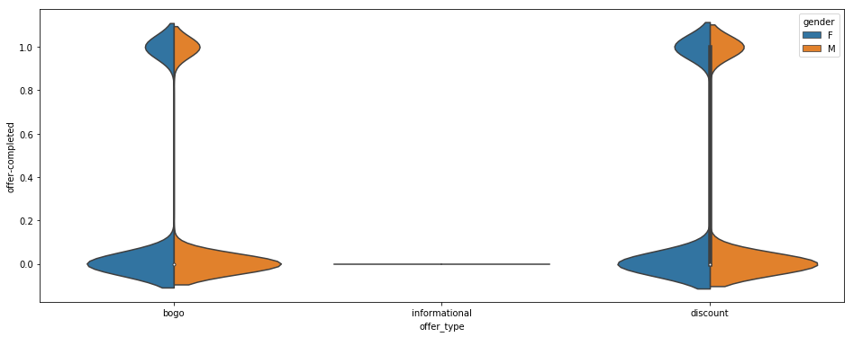

```python
plt.figure(figsize=(16, 6))
sns.violinplot(x ='offer_type', y ='offer-completed', data = df, hue ='gender', split = True)
```

[figure not shown]

```python
plt.figure(figsize=(16, 6))
sns.violinplot(x ='amount', y ='age', data = df, hue ='gender', split = True)
```

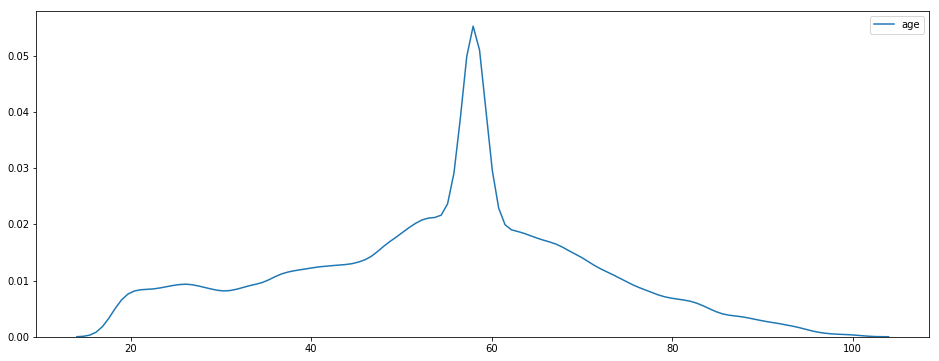

```python
plt.figure(figsize=(16, 6))
sns.kdeplot(df['age'])
```

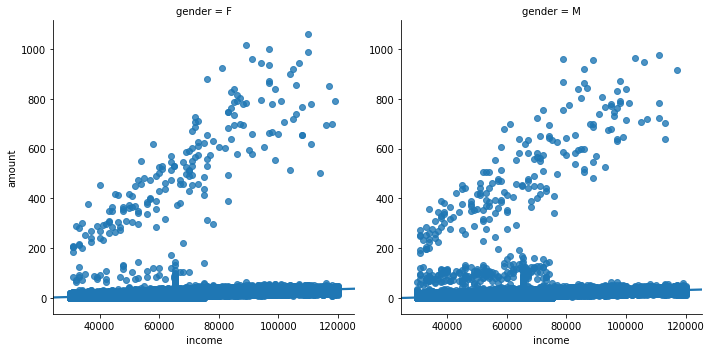

```python
plt.figure(figsize=(16, 6))
sns.lmplot(x="income", y="amount", col="gender", data=df, x_jitter=.05);
```

## Question 1: Is there a link between gender and the amount spent?

```python
df_ml = df.query("transaction == 1")
```

```python
df_ml = df_ml.drop(columns=['offer-completed', 'offer-received', 'offer-viewed', 'offer_id', 'difficulty', 'duration', 'offer_type', 'reward', 'email', 'mobile', 'social', 'web', 'customer_id', 'event_id', 'transaction', 'event', 'time', 'became_member_on'])
df_ml.head()
```

|  | amount | age | gender | income |
| --- | --- | --- | --- | --- |
| 2 | 19.89 | 75.0 | F | 100000.0 |
| 4 | 17.78 | 75.0 | F | 100000.0 |
| 7 | 19.67 | 75.0 | F | 100000.0 |
| 8 | 29.72 | 75.0 | F | 100000.0 |
| 9 | 23.93 | 75.0 | F | 100000.0 |

```python
cat_cols = df_ml.select_dtypes(include=['object'])
cat_cols.head()
```

|  | gender |
| --- | --- |
| 2 | F |
| 4 | F |
| 7 | F |
| 8 | F |
| 9 | F |

```python
#Creating new columns from categorical variables to use these features in ML regression algorithm.
for col in cat_cols:
    try:
        df_ml = pd.concat([df_ml.drop(col, axis=1), pd.get_dummies(df_ml[col], prefix=col, prefix_sep='_', drop_first=True)], axis=1)
    except:
        continue
```

```python
df_ml.head()
```

|  | amount | age | income | gender_M |
| --- | --- | --- | --- | --- |
| 2 | 19.89 | 75.0 | 100000.0 | 0 |
| 4 | 17.78 | 75.0 | 100000.0 | 0 |
| 7 | 19.67 | 75.0 | 100000.0 | 0 |
| 8 | 29.72 | 75.0 | 100000.0 | 0 |
| 9 | 23.93 | 75.0 | 100000.0 | 0 |

```python
#Establishing the X (features) and y (the variable to be modelled) dataframes
y = df_ml['amount']
X = df_ml.drop(columns='amount')
```

```python
#Splitting the new dataframes into train and test dataframes
X_train, X_test, y_train, y_test = train_test_split(X, y, test_size = 0.3, random_state=13)
```

```python
#Applying the linear regression, fitting the model, making predictions with the test set and scoring the success of the model
lm_model = LinearRegression(normalize=True)
lm_model.fit(X_train, y_train)
y_test_preds = lm_model.predict(X_test)
y_train_preds = lm_model.predict(X_train)

test_score = r2_score(y_test, y_test_preds)
train_score = r2_score(y_train, y_train_preds)

print('Test Score:', test_score)
print('Train Score:',train_score)
```

```
Test Score: 0.0517747583242
Train Score: 0.0548726936213
```

```python
#Below function is taken from one of the Udacity jupyter notebook examples. I used this code to see coefficients of my model.
def coef_weights(coefficients, X_train):
    '''
    INPUT:
    coefficients - the coefficients of the linear model
    X_train - the training data, so the column names can be used
    OUTPUT:
    coefs_df - a dataframe holding the coefficient, estimate, and abs(estimate)

    Provides a dataframe that can be used to understand the most influential coefficients
    in a linear model by providing the coefficient estimates along with the name of the
    variable attached to the coefficient.
    '''
    coefs_df = pd.DataFrame()
    coefs_df['est_int'] = X_train.columns
    coefs_df['coefs'] = lm_model.coef_
    coefs_df['abs_coefs'] = np.abs(lm_model.coef_)
    coefs_df = coefs_df.sort_values('abs_coefs', ascending=False)
    return coefs_df

#Use the function
coef_df = coef_weights(lm_model.coef_, X_train)
```

```python
coef_df.head(20)
```

|  | est_int | coefs | abs_coefs |
| --- | --- | --- | --- |
| 2 | gender_M | -2.650917 | 2.650917 |
| 0 | age | 0.022203 | 0.022203 |
| 1 | income | 0.000335 | 0.000335 |

### Conclusion: The dataset is quite imbalanced, therefore the ML model's results are not quite promising.

#### Female users are spending slightly more money comparing to male users. However, there is no significant finding to prove this gender and paid amount correlation.

```python
def find_optimal_number_of_selectors(X, y, k_samples, plot=True, legend=True):
    '''
    INPUT:
    X dataframe that contains the features.
    y dataframe that contains the variable to be predicted.
    k_samples is a list of k values that will be tested.

    OUTPUT:
    A dictionary that contains values of tested k-values as keys and r-squared values for each key.
    The k-value that has the highest r-squared.

    '''
    result_r_squareds = []
    results = {}
    for kes in k_samples:
        selector = SelectKBest(score_func=f_regression, k=kes)
        selector.fit_transform(X, y)
        selected_cols = selector.get_support(indices=True)
        features_new_X = X.iloc[:,selected_cols]

        X_train, X_test, y_train, y_test = train_test_split(features_new_X, y, test_size = 0.3, random_state=42)
        lm_model = LinearRegression(normalize=True)
        lm_model.fit(X_train, y_train)
        y_test_preds = lm_model.predict(X_test)
        result_r_squareds.append(r2_score(y_test, y_test_preds))
        results[str(kes)] = r2_score(y_test, y_test_preds)

    if plot:
        plt.plot(k_samples, result_r_squareds, label="r-squared", alpha=0.7)
        plt.xlabel("Different k_values")
        plt.ylabel("R_Squared_Values")
        plt.legend(loc=1)
        plt.show()

    best_k = max(results, key=results.get)

    return results, best_k
```

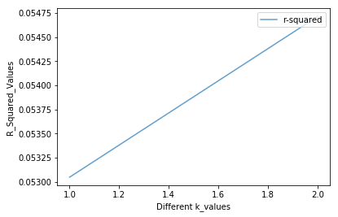

```
{'1': 0.053047481816312692, '2': 0.054713633108344539}
2
0.0547136331083
```

```python
#Testing a range of k values from 10 to 94 (which is the number of all features) to find the number of features generate the highest r-squared value.
k_samples = range(1, len(X.columns))
k_results, best_k = find_optimal_number_of_selectors(X, y, k_samples)
print(k_results)
print(best_k)
print(k_results[best_k])
```

### Question 2: What is the average spending per gender?

```python
df_transcript.head()
```

|  | event | customer_id | time | offer-completed | offer-received | offer-viewed | transaction | offer_id | amount |
| --- | --- | --- | --- | --- | --- | --- | --- | --- | --- |
| 0 | offer-received | 78afa995795e4d85b5d9ceeca43f5fef | 0 | 0 | 1 | 0 | 0 | 9b98b8c7a33c4b65b9aebfe6a799e6d9 | NaN |
| 1 | offer-received | a03223e636434f42ac4c3df47e8bac43 | 0 | 0 | 1 | 0 | 0 | 0b1e1539f2cc45b7b9fa7c272da2e1d7 | NaN |
| 2 | offer-received | e2127556f4f64592b11af22de27a7932 | 0 | 0 | 1 | 0 | 0 | 2906b810c7d4411798c6938adc9daaa5 | NaN |
| 3 | offer-received | 8ec6ce2a7e7949b1bf142def7d0e0586 | 0 | 0 | 1 | 0 | 0 | fafdcd668e3743c1bb461111dcafc2a4 | NaN |
| 4 | offer-received | 68617ca6246f4fbc85e91a2a49552598 | 0 | 0 | 1 | 0 | 0 | 4d5c57ea9a6940dd891ad53e9dbe8da0 | NaN |

```python
df_profile.head()
```

|  | age | became_member_on | gender | customer_id | income |
| --- | --- | --- | --- | --- | --- |
| 0 | 58.0 | 2017-02-12 | None | 68be06ca386d4c31939f3a4f0e3dd783 | 65404.991568 |
| 1 | 55.0 | 2017-07-15 | F | 0610b486422d4921ae7d2bf64640c50b | 112000.000000 |
| 2 | 58.0 | 2018-07-12 | F | 38fe809add3b4fcf9315a9694bb96ff5 | 65404.991568 |
| 3 | 75.0 | 2017-05-09 | F | 78afa995795e4d85b5d9ceeca43f5fef | 100000.000000 |
| 4 | 58.0 | 2017-08-04 | F | a03223e636434f42ac4c3df47e8bac43 | 65404.991568 |

```python
avg_spending = df_transcript[df_transcript['event'] == 'transaction'].merge(df_profile, on='customer_id') \
                                                               .groupby('gender', as_index=False)['amount'] \
                                                               .mean() \
                                                               .rename(columns={'amount': 'average_spending_per_gender'}) \
                                                               .sort_values('average_spending_per_gender')

avg_spending['gender'] = avg_spending['gender'].map({'F': 'Female', 'M': 'Male', 'O': 'Others'})

avg_spending
```

|  | gender | average_spending_per_gender |
| --- | --- | --- |
| 1 | Male | 10.682622 |
| 2 | Others | 13.854927 |
| 0 | Female | 15.791243 |

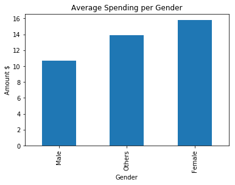

```python
avg_spending.set_index('gender').plot(kind='bar', legend=False)
plt.title('Average Spending per Gender')
plt.xlabel('Gender')
plt.ylabel('Amount $')
plt.show()
```

#### Wrapping up:

- Average spending of female users is approximately 15$.
- Average spending of male users is around 10$.
- Female users are spending almost 5$ more than male users.

### Question 3: Who are the top spending customers?

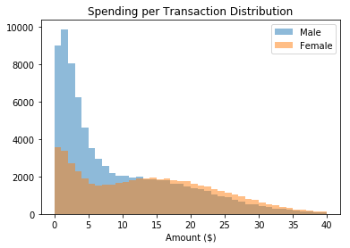

```python
plt.hist(df[df['gender'] == 'M']['amount'], range=(0, 40), alpha=0.5, bins=40, label='Male')
plt.hist(df[df['gender'] == 'F']['amount'], range=(0, 40), alpha=0.5, bins=40, label='Female')
plt.legend(loc='upper right')

plt.title('Spending per Transaction Distribution')
plt.xlabel('Amount ($)')
plt.show()
```

```python
df['customer_id'].nunique()
```

```
16765
```

```python
df['customer_id'].value_counts()[:25]
```

```
94de646f7b6041228ca7dec82adb97d2    51
8dbfa485249f409aa223a2130f40634a    49
d0a80415b84c4df4908b8403b19765e3    48
79d9d4f86aca4bed9290350fb43817c2    48
5e60c6aa3b834e44b822ea43a3efea26    48
b1f4ece7d49342628a9ed77aee2cde58    46
28681c16026943e68f26feaccab0907f    46
a42ed50acc4d4b25bca647c9e0b916ad    46
bd2cdd691aca4bb0a0e039979ee5de5c    46
ab25fd6fbd5040f880751921e4029757    44
86e9d338b85b4177b369fe6b0ad4fed3    43
ca265792e65949d79b2b0e91bdd31c57    43
4142f5e23db741b1af4be0287dc91c1c    43
d087fd0166404163b7d1e1e7cf2a9ac7    43
9ae56116908640fc83477982da0aaec4    43
0d74b166a5e54b269795dbaf38c6dfae    42
40ce078d5b2a43d19138a788754520be    42
cd9bac9e8aea4609929a55b9b468c88e    42
0ebc3c4c39234ab6a2701fe2525705a9    42
edc7b04392144da9979f3077095f268a    42
8e7d398d4bd948e397e201ad2bd5cce8    42
81a263ee0b8544b6a8910ee690cc6edd    41
6cd32ababc644c6c8a2644368c795728    41
1d755c218f714559a57ee7df7e6b1ca0    41
f0a3a3c05e3c4e2e84929a49a6b5488c    41
Name: customer_id, dtype: int64
```

```python
def select_columns(data_frame, column_names):
    new_frame = data_frame.loc[:, column_names]
    return new_frame
```

```python
selected_columns = ['customer_id','amount', 'transaction', 'gender', 'age', 'income', 'became_member_on']
```

```python
best_customers = select_columns(df, selected_columns)
best_customers.head()
```

|  | customer_id | amount | transaction | gender | age | income | became_member_on |
| --- | --- | --- | --- | --- | --- | --- | --- |
| 0 | 78afa995795e4d85b5d9ceeca43f5fef | NaN | 0 | F | 75.0 | 100000.0 | 2017-05-09 |
| 1 | 78afa995795e4d85b5d9ceeca43f5fef | NaN | 0 | F | 75.0 | 100000.0 | 2017-05-09 |
| 2 | 78afa995795e4d85b5d9ceeca43f5fef | 19.89 | 1 | F | 75.0 | 100000.0 | 2017-05-09 |
| 3 | 78afa995795e4d85b5d9ceeca43f5fef | NaN | 0 | F | 75.0 | 100000.0 | 2017-05-09 |
| 4 | 78afa995795e4d85b5d9ceeca43f5fef | 17.78 | 1 | F | 75.0 | 100000.0 | 2017-05-09 |

```python
best_customers_total = df.groupby('customer_id').sum()[['amount']].sort_values(by='amount', ascending=False)[:100]
best_customers_total.info()
```

```
<class 'pandas.core.frame.DataFrame'>
Index: 100 entries, 3c8d541112a74af99e88abbd0692f00e to 8d31a8a4b5d24b10a54da118855f7132
Data columns (total 1 columns):
amount    100 non-null float64
dtypes: float64(1)
memory usage: 1.6+ KB
```

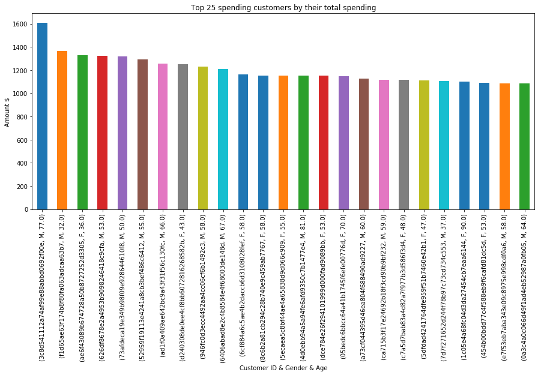

```python
(best_customers.groupby(['customer_id', 'gender', 'age'])['amount'].sum().sort_values(ascending=False))[:25].plot(kind='bar',
    figsize=(15,6))
plt.title('Top 25 spending customers by their total spending');
plt.xlabel('Customer ID & Gender & Age')
plt.ylabel('Amount $')
plt.show()
```

```python
#avr_spending_per_customer = best_customers.groupby(['customer_id'])['amount'].sum() / len(best_customers.groupby(['customer_id'])['transaction'=='1'])
```

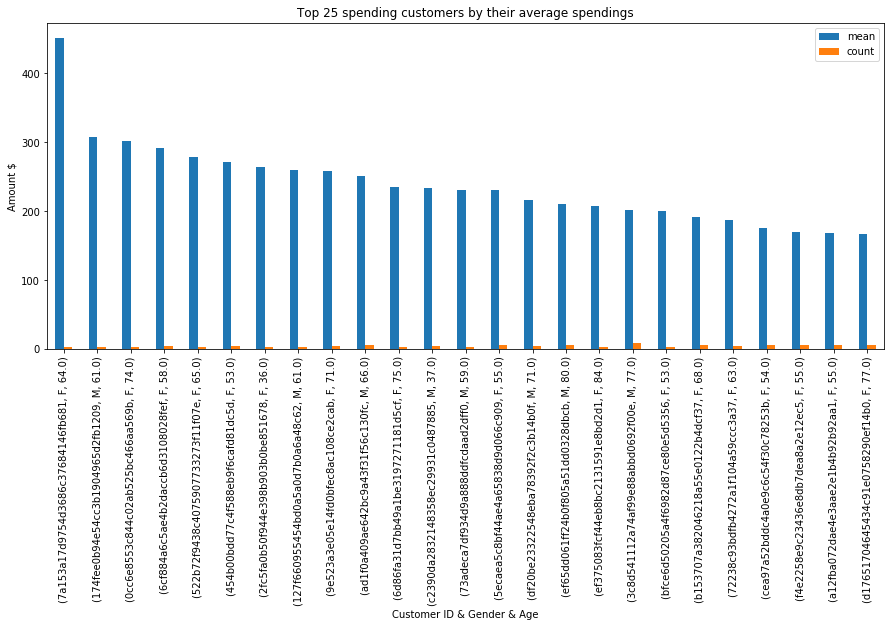

```python
best_customers_grouped = best_customers.groupby(['customer_id', 'gender', 'age']).agg({"amount":["mean", "count"]})
best_customers_grouped['amount'].sort_values("mean", ascending=False)[:25].plot(kind='bar',figsize=(15,6))
plt.title('Top 25 spending customers by their average spendings');
plt.xlabel('Customer ID & Gender & Age')
plt.ylabel('Amount $')
plt.show()
```

#### Wrapping up:

- Top total spending customer with 1608.69 is '3c8d541112a74af99e88abbd0692f00e' who is male customer in the age of 77.
- Top average spending customer with 451 avg. spending is '7a153a17d9754d3686c37684146fb681' who is female customer in the the age of 64.

### Question 4: What are the distiguished groups within the dataset?

```python
df.head()
```

|  | event | customer_id | time | offer-completed | offer-received | offer-viewed | transaction | offer_id | amount | age | ... | income | difficulty | duration | offer_type | reward | email | mobile | social | web | event_id |
| --- | --- | --- | --- | --- | --- | --- | --- | --- | --- | --- | --- | --- | --- | --- | --- | --- | --- | --- | --- | --- | --- |
| 0 | offer-received | 78afa995795e4d85b5d9ceeca43f5fef | 0 | 0 | 1 | 0 | 0 | 0.0 | NaN | 75.0 | ... | 100000.0 | 5.0 | 7.0 | bogo | 5.0 | 1.0 | 1.0 | 0.0 | 1.0 | 0 |
| 1 | offer-viewed | 78afa995795e4d85b5d9ceeca43f5fef | 6 | 0 | 0 | 1 | 0 | 0.0 | NaN | 75.0 | ... | 100000.0 | 5.0 | 7.0 | bogo | 5.0 | 1.0 | 1.0 | 0.0 | 1.0 | 1 |
| 2 | transaction | 78afa995795e4d85b5d9ceeca43f5fef | 132 | 0 | 0 | 0 | 1 | NaN | 19.89 | 75.0 | ... | 100000.0 | NaN | NaN | NaN | NaN | NaN | NaN | NaN | NaN | 2 |
| 3 | offer-completed | 78afa995795e4d85b5d9ceeca43f5fef | 132 | 1 | 0 | 0 | 0 | 0.0 | NaN | 75.0 | ... | 100000.0 | 5.0 | 7.0 | bogo | 5.0 | 1.0 | 1.0 | 0.0 | 1.0 | 3 |
| 4 | transaction | 78afa995795e4d85b5d9ceeca43f5fef | 144 | 0 | 0 | 0 | 1 | NaN | 17.78 | 75.0 | ... | 100000.0 | NaN | NaN | NaN | NaN | NaN | NaN | NaN | NaN | 2 |

5 rows × 22 columns

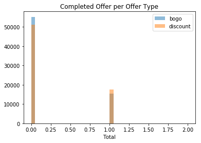

```python
plt.hist(df[df['offer_type'] == 'bogo']['offer-completed'], range=(0, 2), alpha=0.5, bins=40, label='bogo')
plt.hist(df[df['offer_type'] == 'discount']['offer-completed'], range=(0, 2), alpha=0.5, bins=40, label='discount')
plt.legend(loc='upper right')

plt.title('Completed Offer per Offer Type')
plt.xlabel('Total')
plt.show()
```

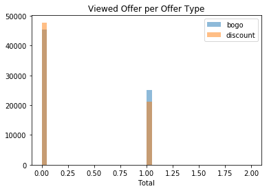

```python
plt.hist(df[df['offer_type'] == 'bogo']['offer-viewed'], range=(0, 2), alpha=0.5, bins=40, label='bogo')
plt.hist(df[df['offer_type'] == 'discount']['offer-viewed'], range=(0, 2), alpha=0.5, bins=40, label='discount')
plt.legend(loc='upper right')

plt.title('Viewed Offer per Offer Type')
plt.xlabel('Total')
plt.show()
```

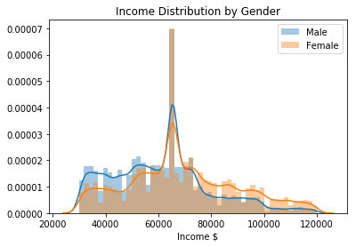

```python
## Gender-wise Income Distribution
sns.distplot(df[df.gender=='M'].income,label='Male')
sns.distplot(df[df.gender=='F'].income,label='Female')
plt.legend()
plt.title('Income Distribution by Gender')
plt.xlabel('Income $')
plt.show()
```

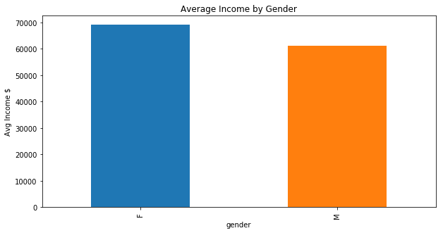

```python
df['income'].groupby(df['gender']).mean().plot(kind='bar',figsize=(10,5))
plt.title('Average Income by Gender');
plt.ylabel('Avg Income $')
plt.show()
```

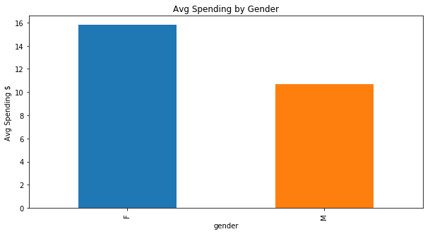

```python
df['amount'].groupby(df['gender']).mean().plot(kind='bar',figsize=(10,5))
plt.title('Avg Spending by Gender');
plt.ylabel('Avg Spending $')
plt.show()
```

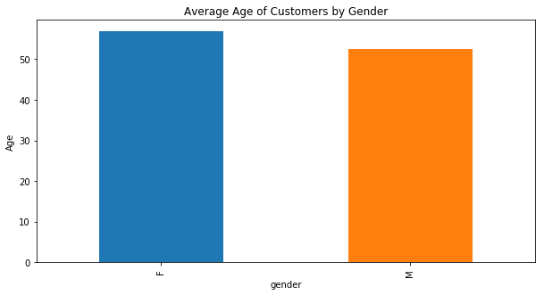

```python
df['age'].groupby(df['gender']).mean().plot(kind='bar',figsize=(10,5))
plt.title('Average Age of Customers by Gender');
plt.ylabel('Age')
plt.show()
```

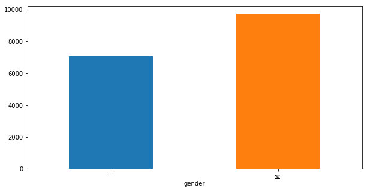

```python
df['customer_id'].groupby(df['gender']).nunique().plot(kind='bar',figsize=(10,5))
plt.show()
```

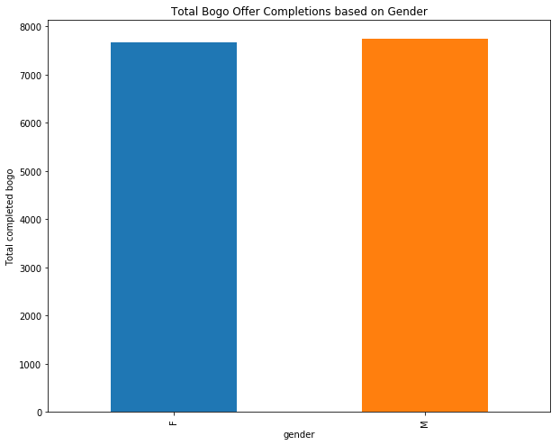

```python
df['offer-completed'].loc[(df['offer-completed'] == 1) & (df['offer_type'] == 'bogo')].groupby(df['gender']).sum().plot(kind='bar',figsize=(10,8))
plt.title('Total Bogo Offer Completions based on Gender');
plt.ylabel('Total completed bogo')
plt.show()
```

```python
df['offer-completed'].loc[(df['offer-completed'] == 1) & (df['offer_type'] == 'bogo')].groupby(df['gender']).sum()
```

```
gender
F    7675.0
M    7741.0
Name: offer-completed, dtype: float64
```

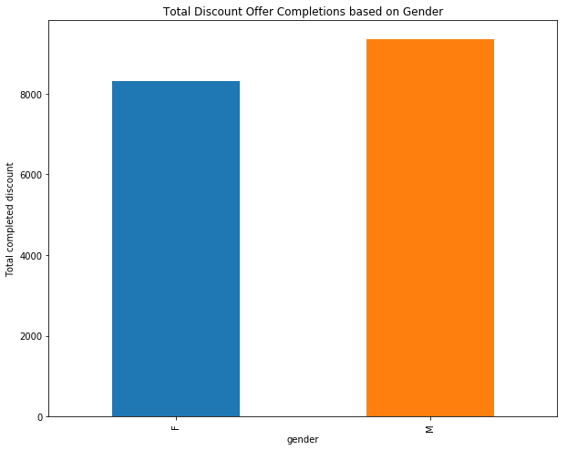

```python
df['offer-completed'].loc[(df['offer-completed'] == 1) & (df['offer_type'] == 'discount')].groupby(df['gender']).sum().plot(kind='bar',figsize=(10,8))
plt.title('Total Discount Offer Completions based on Gender');
plt.ylabel('Total completed discount')
plt.show()
```

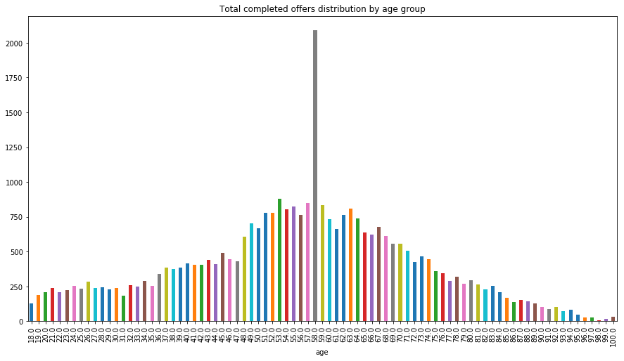

```python
df['offer-completed'].loc[(df['offer-completed'] == 1)].groupby(df['age']).sum().plot(kind='bar',figsize=(15,8))

plt.title('Total completed offers distribution by age group');
plt.show()
```

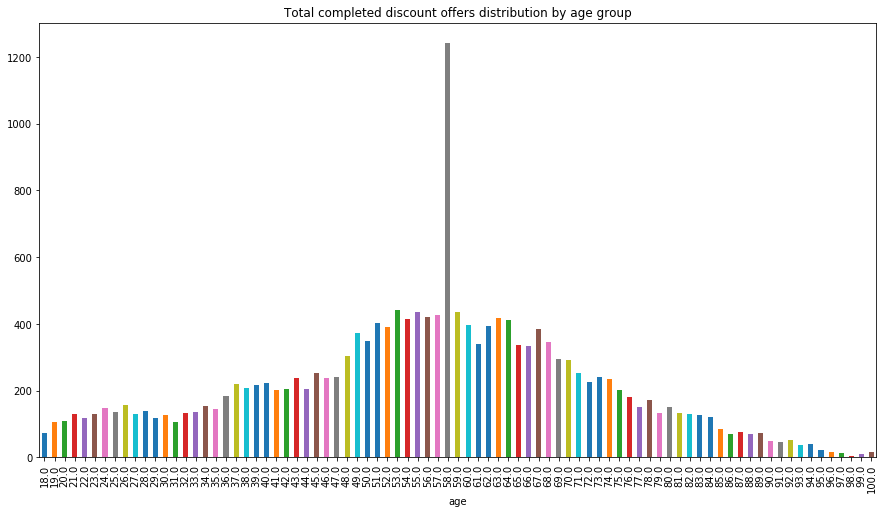

```python
df['offer-completed'].loc[(df['offer-completed'] == 1) & (df['offer_type'] == 'discount')].groupby(df['age']).sum().plot(kind='bar',figsize=(15,8))

plt.title('Total completed discount offers distribution by age group');
plt.show()
```

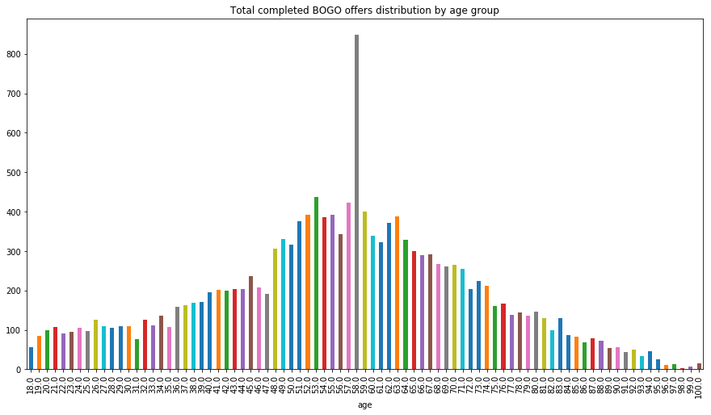

```python
df['offer-completed'].loc[(df['offer-completed'] == 1) & (df['offer_type'] == 'bogo')].groupby(df['age']).sum().plot(kind='bar',figsize=(15,8))

plt.title('Total completed BOGO offers distribution by age group');
plt.show()
```

### Completed offers based on sent channels and grouped by gender as:

Channels:

- Email
- Web
- Social
- Web

Gender:

- Female
- Male

```python
df['offer-completed'].loc[(df['offer-completed'] == 1) & (df['email'] == 1.0)].groupby(df['gender']).sum()
```

```
gender
F    15973.0
M    17088.0
Name: offer-completed, dtype: float64
```

```python
df['offer-completed'].loc[(df['offer-completed'] == 1) & (df['social'] == 1.0)].groupby(df['gender']).sum()
```

```
gender
F    10302.0
M    11169.0
Name: offer-completed, dtype: float64
```

```python
df['offer-completed'].loc[(df['offer-completed'] == 1) & (df['web'] == 1.0)].groupby(df['gender']).sum()
```

```
gender
F    14100.0
M    15332.0
Name: offer-completed, dtype: float64
```

```python
df['offer-completed'].loc[(df['offer-completed'] == 1) & (df['mobile'] == 1.0)].groupby(df['gender']).sum()
```

```
gender
F    14254.0
M    15450.0
Name: offer-completed, dtype: float64
```

### Completed offers based on sent channels and grouped by offer types as:

- Bogo
- Discount

```python
df['offer-completed'].loc[(df['offer-completed'] == 1) & (df['email'] == 1.0)].groupby(df['offer_type']).sum()
```

```
offer_type
bogo        15416.0
discount    17647.0
Name: offer-completed, dtype: float64
```

```python
df['offer-completed'].loc[(df['offer-completed'] == 1) & (df['social'] == 1.0)].groupby(df['offer_type']).sum()
```

```
offer_type
bogo        11138.0
discount    10335.0
Name: offer-completed, dtype: float64
```

```python
df['offer-completed'].loc[(df['offer-completed'] == 1) & (df['web'] == 1.0)].groupby(df['offer_type']).sum()
```

```
offer_type
bogo        11787.0
discount    17647.0
Name: offer-completed, dtype: float64
```

```python
df['offer-completed'].loc[(df['offer-completed'] == 1) & (df['mobile'] == 1.0)].groupby(df['offer_type']).sum()
```

```
offer_type
bogo        15416.0
discount    14290.0
Name: offer-completed, dtype: float64
```

#### Suggestions for improvement:

- Focus on Web and Email channels for better retention of Discount offers. By contrast, more activation needed for more retention towards BOGO offers on Social and Mobile channels.
- Alter the existing marketing strategy for attracting millennials and gen Z. Apparently, the current strategy more influential on older generations.
- On the other hand, try to motivate male users to spend more money on average.

```python
from subprocess import call
call(['python', '-m', 'nbconvert', 'Starbucks_Capstone_notebook.ipynb'])
```

```
0
```